# ÉTUDE GÉNÉRALISÉE DE LA SOUS-NUTRITION DANS LE MONDE

## *III.2. Autres utilisations alimentaires*

Comme pour la partie précédente, voyons ce que 10% de ces "autres utilisations" pourrait libérer comme potentiel alimentaire.

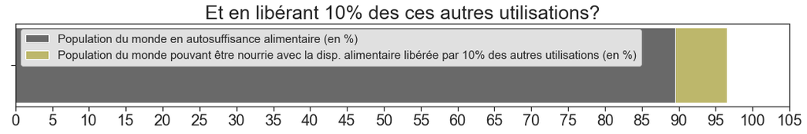

```python
NA1P=10*world["other_uses"].sum()/FQ

barre_nutritive(PRCN, NA1P, "dimgray", "monde", "10% des autres utilisations", 106)

plt.title("Et en libérant 10% des ces autres utilisations?", fontsize=25)
plt.show()
```

Ces résultats montrent que si l'on montait à 20% de réorientation de ces autres utilisations vers de la nourriture pour l'homme, pourrait libérer de quoi sauver le monde de la faim, également.

## *III.3. Taux d'exportations*

Enfin, nous exploiterons un dernier critère contribuant à la sous-nutrition dans les pays les plus pauvres qui est le taux d'exportations. Nous avons vu que les pays les plus riches présentaient une disponibilité alimentaire excédentaire, à l'inverse des pays dans le besoin qui, eux, ne disposent pas des ressources nécessaires pour nourrir leur population. Nous verrons cependant que dans certains pays, une réorganisation alimentaire locale permettrait de subvenir aux besoins des habitants sous-alimentés.

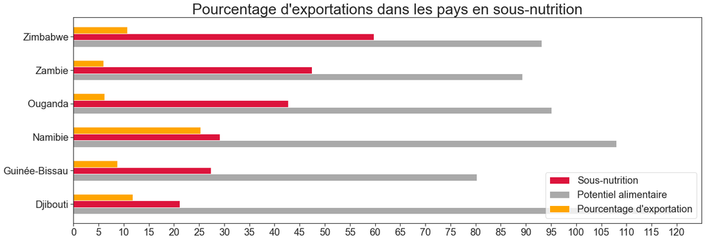

```python
ba=world.loc[world.index.isin(["Guinée-Bissau",
                               "Zambie",
                               "Ouganda",
                               "Namibie",
                               "Djibouti",
                               "Zimbabwe"])]

x, y1, y2, y3 = range(len(ba)), ba["und_percentage"], ba["potentiel"], ba["exportation"]

dim(20, 7)

plt.barh(x, y1, height=0.2, label="Sous-nutrition", color="crimson")
plt.barh([i-0.2 for i in x], y2,  height=0.2, label="Potentiel alimentaire", color="darkgrey")
plt.barh([i+0.2 for i in x] , y3,  height=0.2, label="Pourcentage d'exportation", color="orange")

plt.xticks(range(0, 121, 5), fontsize=20)
plt.yticks(fontsize=20)
plt.legend(fontsize=20, loc="lower right")
plt.yticks(range(len(ba)), [i for i in ba.index])
plt.title("Pourcentage d'exportations dans les pays en sous-nutrition", fontsize=30)
plt.tight_layout()
plt.show()
```

Nous avons détecté des pays en sous-nutrition critique où les taux d'exportations alimentaires étaient relativement important. En effet, certains chefs d'état semblent privilégier un apport financier au détriment de la rassasion de leur peuple, souffrant pourtant de la famine. Observons que chacun des pays choisis pour mettre cet aspect en avant témoignent d'un potentiel alimentaire insuffisant, ou au mieux extrêmement fragile. Plus de 20% de la population de ces pays est en sous-nutrition, allant même au-delà des 40% pour l'Ouganda, la Zambie et la Zimbabwe. Et nous relevons des taux d'exportations de plus de 5%, allant jusqu'à 25% pour la Namibie. Il est donc important de souligner ces disproportions. Bien que l'on s'en prenne à des dispositifs commerciaux qui dépassent le cadre de ce projet, nos valeurs tendent à prioriser la sassité de l'être humain, avant toute autre oeuvre marchande ou commerciale.

*Retour au sommaire*

# IV. Conclusion

**La faim dans le monde est un combat perpétuel que nous menons depuis des siècles. La première victoire de l'humanité sur ce fléau est sa capacité à nourrir le monde entier, comme nous avons pu le voir et le rappeler tout au long du projet. Il s'agit maintenant d'utiliser la disponibilité alimentaire mondiale à bon escient. Nous avons vu que certains pays comme l'Algérie, la Roumanie ou encore le Mexique (Cluster 5) relevaient la sous-nutrition malgré un potentiel alimentaire auto-satisfaisant. La politique de gestion alimentaire serait donc à revoir au sein même de ces pays pour faire disparaître la famine. Les relations internationales avec les pays autosuffisants jouent également un rôle clef dans cette lutte. Les exploitations agricoles pour le compte de certaines multinationales ne sont pas suffisamment dirigées vers les peuples en sous-nutrition. Nous pouvons citer l'exemple des transactions foncières au Brésil, où les habitants se voient privés de certaines terres agricoles susceptibles de sauver une partie de la population locale. Nous avons pu voir également en fin de mission 4 une variable peu exploitée qui est le pourcentage d'exportations de la disponibilité alimentaire, où nous avons vu que certains pays en sous-nutrition comme la Zimbabwe ou l'Ouganda se tournaient vers des bénéfices extérieurs liés à l'exportation agricole au détriment de la nurtrition de leur peuple. Enfin, nous mettrons surtout en avant dans cette conclusion la mauvaise répartition de la disponibilité alimentaire mondiale. Des pays comme le Libéria et la République Centrafricaine ne disposent pas de quoi nourrir leur peuple, nous avons relevé des potentiels alimentaires particulièrement bas dans ces deux derniers pays, pour chacune des deux unités d'énergie. Nous pouvons proposer un plan en trois étapes qui consiterait à orienter les aides alimentaires internationales et humanitaires et vers les pays relevés dans le Cluster 2 ainsi que vers l'Inde en priorité, réorganiser la politique de gestion alimentaire pour la Chine et les pays des Cluster 5 et 4, pour ensuite orienté ces mêmes aides vers le Cluster 4. Ce plan peut paraître ambitieux, mais demeure réalisable en vertue des données de dispositions alimentaires présentées dans ce projet, et pourrait - espérons-le - enfin mettre un terme à la famine aux quatre coins du monde.**

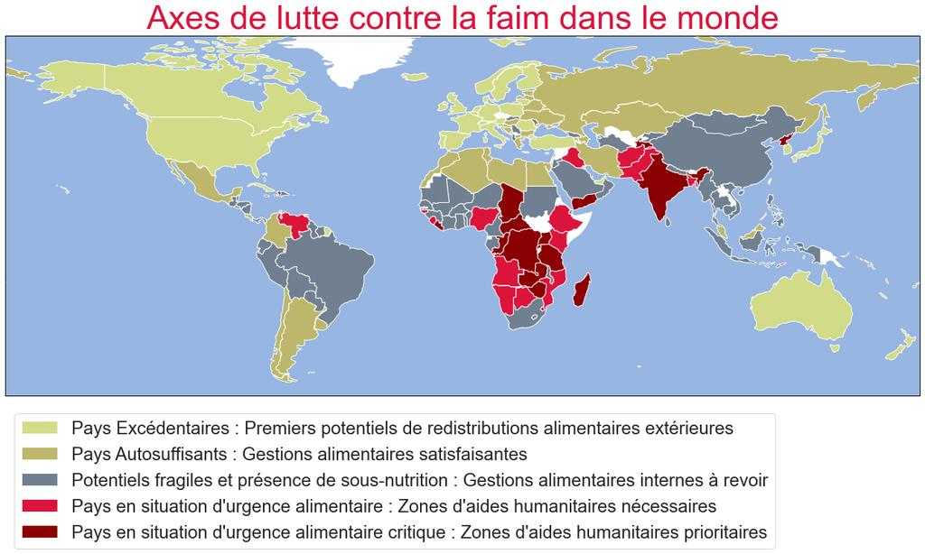

```python
world=pd.read_csv("data/projet_R/world.csv").set_index("country")

world["categorie"]=np.NaN


for i in world.index:

    CLUST = world.loc[world.index==i]["cluster"].values[0]
    POTENTIEL = world.loc[world.index==i]["potentiel"].values[0]
    UNDPER = world.loc[world.index==i]["und_percentage"].values[0]

    if CLUST == 2: world.loc[world.index==i, "categorie"] = "UA"

    if CLUST == 3: world.loc[world.index==i, "categorie"] = "PE"

    if CLUST == 4:
        if POTENTIEL <= 100:
            world.loc[world.index==i, "categorie"] = "UA"
        else :
            world.loc[world.index==i, "categorie"] = "PF"

    if CLUST == 5:
        if UNDPER == 0:
            if POTENTIEL >= 150:
                world.loc[world.index==i, "categorie"] = "PE"
            else :
                world.loc[world.index==i, "categorie"] = "PA"
        else:
            if UNDPER >=5:
                world.loc[world.index==i, "categorie"] = "PF"
            else:
                world.loc[world.index==i, "categorie"] = "PA"

    if UNDPER >= 30: world.loc[world.index==i, "categorie"] = "UAP"


world.loc[world.index=="Chine", "categorie"]="PF"
world.loc[world.index=="Inde", "categorie"]="UAP"

palette=["#D1DB88", "darkkhaki", "slategray", "crimson", "darkred"]

def categ(CAT): return(mapzone(world.loc[world["categorie"]==CAT]))

P1, P2, P3, P4, P5 = categ("PE"), categ("PA"), categ("PF"), categ("UA"), categ("UAP")


dim(22, 12)

ax = plt.axes(projection=ccrs.PlateCarree())
ax = carte(ax)

cartography([P1, P2, P3, P4, P5], palette, ax)

ax.legend(legendes(palette),
          ["Pays Excédentaires : Premiers potentiels de redistributions alimentaires extérieures",
           "Pays Autosuffisants : Gestions alimentaires satisfaisantes",
           "Potentiels fragiles et présence de sous-nutrition : Gestions alimentaires internes à revoir",
           "Pays en situation d'urgence alimentaire : Zones d'aides humanitaires nécessaires",
           "Pays en situation d'urgence alimentaire critique : Zones d'aides humanitaires prioritaires"],
           fontsize=24, loc="lower left", bbox_to_anchor=(0, -0.45))

plt.title("Axes de lutte contre la faim dans le monde", fontsize=45, color="crimson")
plt.show()
```